# Risk Factor Analysis

## Outcome Variable

**Outcome Variable:** stunted

## Predictor Variables

**Intervention Variable:** exclfeed36

**Adjustment Set:**

unadjusted

## Stratifying Variables

The analysis was stratified on these variable(s):

- agecat
- studyid
- country

## Data Summary

| agecat | studyid | country | exclfeed36 | stunted | n_cell | n |
| --- | --- | --- | --- | --- | --- | --- |
| Birth | CMC-V-BCS-2002 | INDIA | 1 | 0 | 3 | 3 |
| Birth | CMC-V-BCS-2002 | INDIA | 1 | 1 | 0 | 3 |
| Birth | CMC-V-BCS-2002 | INDIA | 0 | 0 | 0 | 3 |
| Birth | CMC-V-BCS-2002 | INDIA | 0 | 1 | 0 | 3 |
| Birth | EE | PAKISTAN | 1 | 0 | 2 | 7 |
| Birth | EE | PAKISTAN | 1 | 1 | 1 | 7 |
| Birth | EE | PAKISTAN | 0 | 0 | 3 | 7 |
| Birth | EE | PAKISTAN | 0 | 1 | 1 | 7 |
| Birth | GMS-Nepal | NEPAL | 1 | 0 | 356 | 526 |
| Birth | GMS-Nepal | NEPAL | 1 | 1 | 66 | 526 |
| Birth | GMS-Nepal | NEPAL | 0 | 0 | 85 | 526 |
| Birth | GMS-Nepal | NEPAL | 0 | 1 | 19 | 526 |
| Birth | IRC | INDIA | 1 | 0 | 0 | 4 |
| Birth | IRC | INDIA | 1 | 1 | 0 | 4 |
| Birth | IRC | INDIA | 0 | 0 | 3 | 4 |
| Birth | IRC | INDIA | 0 | 1 | 1 | 4 |
| Birth | JiVitA-3 | BANGLADESH | 1 | 0 | 5638 | 10681 |
| Birth | JiVitA-3 | BANGLADESH | 1 | 1 | 2684 | 10681 |
| Birth | JiVitA-3 | BANGLADESH | 0 | 0 | 1588 | 10681 |
| Birth | JiVitA-3 | BANGLADESH | 0 | 1 | 771 | 10681 |
| Birth | JiVitA-4 | BANGLADESH | 1 | 0 | 1406 | 2517 |
| Birth | JiVitA-4 | BANGLADESH | 1 | 1 | 588 | 2517 |
| Birth | JiVitA-4 | BANGLADESH | 0 | 0 | 350 | 2517 |
| Birth | JiVitA-4 | BANGLADESH | 0 | 1 | 173 | 2517 |
| Birth | Keneba | GAMBIA | 1 | 0 | 347 | 1253 |
| Birth | Keneba | GAMBIA | 1 | 1 | 16 | 1253 |
| Birth | Keneba | GAMBIA | 0 | 0 | 839 | 1253 |
| Birth | Keneba | GAMBIA | 0 | 1 | 51 | 1253 |
| Birth | MAL-ED | BANGLADESH | 1 | 0 | 28 | 221 |
| Birth | MAL-ED | BANGLADESH | 1 | 1 | 4 | 221 |

[output cut: 162 more lines]

The following strata were considered:

- agecat: 24 months, studyid: CMC-V-BCS-2002, country: INDIA
- agecat: 24 months, studyid: EE, country: PAKISTAN
- agecat: 24 months, studyid: GMS-Nepal, country: NEPAL
- agecat: 24 months, studyid: IRC, country: INDIA
- agecat: 24 months, studyid: JiVitA-3, country: BANGLADESH
- agecat: 24 months, studyid: JiVitA-4, country: BANGLADESH
- agecat: 24 months, studyid: Keneba, country: GAMBIA
- agecat: 24 months, studyid: LCNI-5, country: MALAWI
- agecat: 24 months, studyid: MAL-ED, country: BANGLADESH
- agecat: 24 months, studyid: MAL-ED, country: BRAZIL
- agecat: 24 months, studyid: MAL-ED, country: INDIA
- agecat: 24 months, studyid: MAL-ED, country: NEPAL
- agecat: 24 months, studyid: MAL-ED, country: PERU
- agecat: 24 months, studyid: MAL-ED, country: SOUTH AFRICA
- agecat: 24 months, studyid: MAL-ED, country: TANZANIA, UNITED REPUBLIC OF
- agecat: 24 months, studyid: PROVIDE, country: BANGLADESH
- agecat: 6 months, studyid: CMC-V-BCS-2002, country: INDIA
- agecat: 6 months, studyid: EE, country: PAKISTAN
- agecat: 6 months, studyid: GMS-Nepal, country: NEPAL
- agecat: 6 months, studyid: IRC, country: INDIA
- agecat: 6 months, studyid: JiVitA-3, country: BANGLADESH
- agecat: 6 months, studyid: JiVitA-4, country: BANGLADESH
- agecat: 6 months, studyid: Keneba, country: GAMBIA
- agecat: 6 months, studyid: LCNI-5, country: MALAWI
- agecat: 6 months, studyid: MAL-ED, country: BANGLADESH
- agecat: 6 months, studyid: MAL-ED, country: BRAZIL
- agecat: 6 months, studyid: MAL-ED, country: INDIA
- agecat: 6 months, studyid: MAL-ED, country: NEPAL
- agecat: 6 months, studyid: MAL-ED, country: PERU
- agecat: 6 months, studyid: MAL-ED, country: SOUTH AFRICA
- agecat: 6 months, studyid: MAL-ED, country: TANZANIA, UNITED REPUBLIC OF
- agecat: 6 months, studyid: PROVIDE, country: BANGLADESH
- agecat: 6 months, studyid: SAS-FoodSuppl, country: INDIA
- agecat: Birth, studyid: CMC-V-BCS-2002, country: INDIA
- agecat: Birth, studyid: EE, country: PAKISTAN
- agecat: Birth, studyid: GMS-Nepal, country: NEPAL
- agecat: Birth, studyid: IRC, country: INDIA
- agecat: Birth, studyid: JiVitA-3, country: BANGLADESH
- agecat: Birth, studyid: JiVitA-4, country: BANGLADESH
- agecat: Birth, studyid: Keneba, country: GAMBIA
- agecat: Birth, studyid: MAL-ED, country: BANGLADESH
- agecat: Birth, studyid: MAL-ED, country: BRAZIL
- agecat: Birth, studyid: MAL-ED, country: INDIA
- agecat: Birth, studyid: MAL-ED, country: NEPAL
- agecat: Birth, studyid: MAL-ED, country: PERU
- agecat: Birth, studyid: MAL-ED, country: SOUTH AFRICA
- agecat: Birth, studyid: MAL-ED, country: TANZANIA, UNITED REPUBLIC OF
- agecat: Birth, studyid: PROVIDE, country: BANGLADESH

### Dropped Strata

Some strata were dropped due to rare outcomes:

- agecat: Birth, studyid: CMC-V-BCS-2002, country: INDIA
- agecat: Birth, studyid: EE, country: PAKISTAN
- agecat: Birth, studyid: IRC, country: INDIA
- agecat: Birth, studyid: MAL-ED, country: BANGLADESH
- agecat: Birth, studyid: MAL-ED, country: BRAZIL
- agecat: Birth, studyid: MAL-ED, country: INDIA
- agecat: Birth, studyid: MAL-ED, country: NEPAL
- agecat: Birth, studyid: MAL-ED, country: PERU
- agecat: Birth, studyid: MAL-ED, country: SOUTH AFRICA
- agecat: Birth, studyid: MAL-ED, country: TANZANIA, UNITED REPUBLIC OF
- agecat: 6 months, studyid: CMC-V-BCS-2002, country: INDIA
- agecat: 6 months, studyid: EE, country: PAKISTAN
- agecat: 6 months, studyid: IRC, country: INDIA
- agecat: 6 months, studyid: MAL-ED, country: BRAZIL
- agecat: 6 months, studyid: MAL-ED, country: INDIA
- agecat: 6 months, studyid: MAL-ED, country: NEPAL
- agecat: 6 months, studyid: MAL-ED, country: PERU
- agecat: 6 months, studyid: MAL-ED, country: SOUTH AFRICA
- agecat: 6 months, studyid: MAL-ED, country: TANZANIA, UNITED REPUBLIC OF
- agecat: 6 months, studyid: SAS-FoodSuppl, country: INDIA
- agecat: 24 months, studyid: CMC-V-BCS-2002, country: INDIA
- agecat: 24 months, studyid: EE, country: PAKISTAN
- agecat: 24 months, studyid: IRC, country: INDIA
- agecat: 24 months, studyid: MAL-ED, country: BRAZIL
- agecat: 24 months, studyid: MAL-ED, country: INDIA
- agecat: 24 months, studyid: MAL-ED, country: NEPAL
- agecat: 24 months, studyid: MAL-ED, country: PERU
- agecat: 24 months, studyid: MAL-ED, country: SOUTH AFRICA
- agecat: 24 months, studyid: MAL-ED, country: TANZANIA, UNITED REPUBLIC OF

## Methods Detail

We’re interested in the causal parameters $E[Y_a]$ for all values of $a \in \mathcal{A}$. These parameters represent the mean outcome if, possibly contrary to fact, we intervened to set all units to have $A=a$. Under the randomization and positivity assumptions, these are identified by the statistical parameters $\psi_a=E_W[E_{Y|A,W}(Y|A=a,W)]$. In addition, we’re interested in the mean of $Y$, $E[Y]$ under no intervention (the observed mean). We will estimate these parameters by using SuperLearner to fit the relevant likelihood factors – $E_{Y|A,W}(Y|A=a,W)$ and $p(A=a|W)$, and then updating our likelihood fit using a joint TMLE.

For unadjusted analyses ($W=\{\}$), initial likelihoods were estimated using Lrnr_glm to estimate the simple $E(Y|A)$ and Lrnr_mean to estimate $p(A)$. For adjusted analyses, a small library containing Lrnr_glmnet, Lrnr_xgboost, and Lrnr_mean was used.

Having estimated these parameters, we will then use the delta method to estimate relative risks and attributable risks relative to a prespecified baseline level of $A$.

# Results Detail

## Results Plots

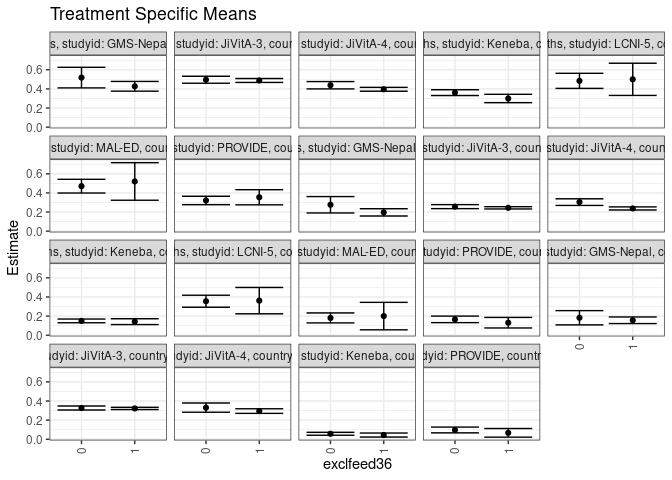

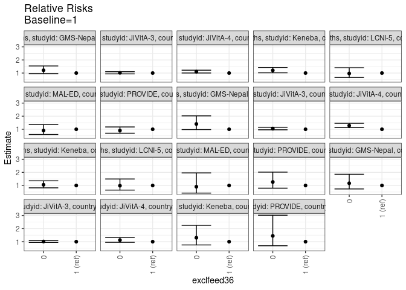

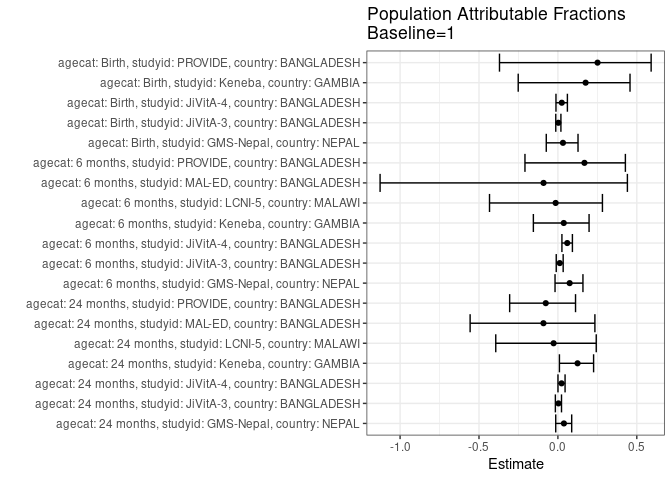

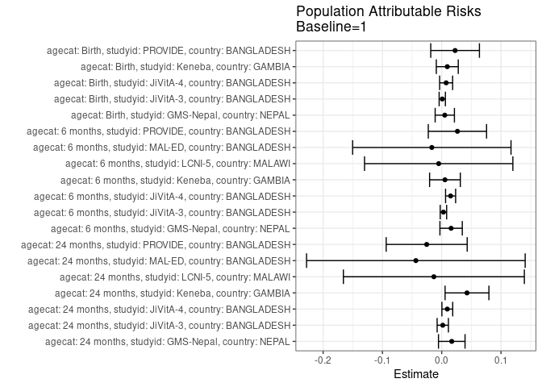

## Results Table

### Parameter: TSM

| agecat | studyid | country | intervention_level | baseline_level | estimate | ci_lower | ci_upper |
| --- | --- | --- | --- | --- | --- | --- | --- |
| Birth | GMS-Nepal | NEPAL | 1 | NA | 0.1563981 | 0.1217093 | 0.1910869 |
| Birth | GMS-Nepal | NEPAL | 0 | NA | 0.1826923 | 0.1083566 | 0.2570280 |
| Birth | JiVitA-3 | BANGLADESH | 1 | NA | 0.3225186 | 0.3107697 | 0.3342676 |
| Birth | JiVitA-3 | BANGLADESH | 0 | NA | 0.3268334 | 0.3058405 | 0.3478263 |
| Birth | JiVitA-4 | BANGLADESH | 1 | NA | 0.2948847 | 0.2709517 | 0.3188176 |
| Birth | JiVitA-4 | BANGLADESH | 0 | NA | 0.3307839 | 0.2825025 | 0.3790653 |
| Birth | Keneba | GAMBIA | 1 | NA | 0.0440771 | 0.0229526 | 0.0652016 |
| Birth | Keneba | GAMBIA | 0 | NA | 0.0573034 | 0.0420276 | 0.0725791 |
| Birth | PROVIDE | BANGLADESH | 1 | NA | 0.0672269 | 0.0221890 | 0.1122648 |
| Birth | PROVIDE | BANGLADESH | 0 | NA | 0.0970350 | 0.0668838 | 0.1271862 |
| 6 months | GMS-Nepal | NEPAL | 1 | NA | 0.1966825 | 0.1587221 | 0.2346429 |
| 6 months | GMS-Nepal | NEPAL | 0 | NA | 0.2761905 | 0.1905888 | 0.3617922 |
| 6 months | JiVitA-3 | BANGLADESH | 1 | NA | 0.2442992 | 0.2324362 | 0.2561621 |
| 6 months | JiVitA-3 | BANGLADESH | 0 | NA | 0.2568389 | 0.2359212 | 0.2777567 |
| 6 months | JiVitA-4 | BANGLADESH | 1 | NA | 0.2375810 | 0.2213939 | 0.2537681 |
| 6 months | JiVitA-4 | BANGLADESH | 0 | NA | 0.3040254 | 0.2694184 | 0.3386324 |
| 6 months | Keneba | GAMBIA | 1 | NA | 0.1420118 | 0.1116192 | 0.1724045 |
| 6 months | Keneba | GAMBIA | 0 | NA | 0.1496493 | 0.1301242 | 0.1691743 |
| 6 months | LCNI-5 | MALAWI | 1 | NA | 0.3617021 | 0.2240807 | 0.4993236 |
| 6 months | LCNI-5 | MALAWI | 0 | NA | 0.3555556 | 0.2928937 | 0.4182174 |
| 6 months | MAL-ED | BANGLADESH | 1 | NA | 0.2000000 | 0.0565653 | 0.3434347 |
| 6 months | MAL-ED | BANGLADESH | 0 | NA | 0.1809524 | 0.1287751 | 0.2331297 |
| 6 months | PROVIDE | BANGLADESH | 1 | NA | 0.1310345 | 0.0760654 | 0.1860036 |
| 6 months | PROVIDE | BANGLADESH | 0 | NA | 0.1659389 | 0.1318393 | 0.2000384 |
| 24 months | GMS-Nepal | NEPAL | 1 | NA | 0.4269972 | 0.3760556 | 0.4779389 |
| 24 months | GMS-Nepal | NEPAL | 0 | NA | 0.5180723 | 0.4104549 | 0.6256897 |
| 24 months | JiVitA-3 | BANGLADESH | 1 | NA | 0.4878195 | 0.4674393 | 0.5081998 |
| 24 months | JiVitA-3 | BANGLADESH | 0 | NA | 0.4955401 | 0.4591818 | 0.5318985 |
| 24 months | JiVitA-4 | BANGLADESH | 1 | NA | 0.3958665 | 0.3757182 | 0.4160147 |
| 24 months | JiVitA-4 | BANGLADESH | 0 | NA | 0.4380531 | 0.3995818 | 0.4765244 |
| 24 months | Keneba | GAMBIA | 1 | NA | 0.2995283 | 0.2559134 | 0.3431432 |
| 24 months | Keneba | GAMBIA | 0 | NA | 0.3608247 | 0.3305921 | 0.3910574 |
| 24 months | LCNI-5 | MALAWI | 1 | NA | 0.5000000 | 0.3314881 | 0.6685119 |
| 24 months | LCNI-5 | MALAWI | 0 | NA | 0.4838710 | 0.4049889 | 0.5627530 |
| 24 months | MAL-ED | BANGLADESH | 1 | NA | 0.5200000 | 0.3236969 | 0.7163031 |
| 24 months | MAL-ED | BANGLADESH | 0 | NA | 0.4705882 | 0.3988796 | 0.5422968 |
| 24 months | PROVIDE | BANGLADESH | 1 | NA | 0.3546099 | 0.2755781 | 0.4336417 |
| 24 months | PROVIDE | BANGLADESH | 0 | NA | 0.3211009 | 0.2772373 | 0.3649646 |

### Parameter: E(Y)

| agecat | studyid | country | intervention_level | baseline_level | estimate | ci_lower | ci_upper |
| --- | --- | --- | --- | --- | --- | --- | --- |
| Birth | GMS-Nepal | NEPAL | NA | NA | 0.1615970 | 0.1301114 | 0.1930825 |
| Birth | JiVitA-3 | BANGLADESH | NA | NA | 0.3234716 | 0.3131402 | 0.3338029 |
| Birth | JiVitA-4 | BANGLADESH | NA | NA | 0.3023441 | 0.2806174 | 0.3240708 |
| Birth | Keneba | GAMBIA | NA | NA | 0.0534717 | 0.0410100 | 0.0659333 |
| Birth | PROVIDE | BANGLADESH | NA | NA | 0.0897959 | 0.0644568 | 0.1151350 |
| 6 months | GMS-Nepal | NEPAL | NA | NA | 0.2125237 | 0.1775632 | 0.2474842 |
| 6 months | JiVitA-3 | BANGLADESH | NA | NA | 0.2471936 | 0.2366536 | 0.2577336 |
| 6 months | JiVitA-4 | BANGLADESH | NA | NA | 0.2525687 | 0.2374550 | 0.2676823 |
| 6 months | Keneba | GAMBIA | NA | NA | 0.1474860 | 0.1310548 | 0.1639172 |
| 6 months | LCNI-5 | MALAWI | NA | NA | 0.3566176 | 0.2995882 | 0.4136471 |
| 6 months | MAL-ED | BANGLADESH | NA | NA | 0.1833333 | 0.1342773 | 0.2323893 |
| 6 months | PROVIDE | BANGLADESH | NA | NA | 0.1575456 | 0.1284434 | 0.1866478 |
| 24 months | GMS-Nepal | NEPAL | NA | NA | 0.4439462 | 0.3977834 | 0.4901089 |
| 24 months | JiVitA-3 | BANGLADESH | NA | NA | 0.4896170 | 0.4715168 | 0.5077172 |
| 24 months | JiVitA-4 | BANGLADESH | NA | NA | 0.4052853 | 0.3865623 | 0.4240082 |
| 24 months | Keneba | GAMBIA | NA | NA | 0.3421808 | 0.3172662 | 0.3670954 |
| 24 months | LCNI-5 | MALAWI | NA | NA | 0.4867725 | 0.4153250 | 0.5582200 |
| 24 months | MAL-ED | BANGLADESH | NA | NA | 0.4764151 | 0.4090254 | 0.5438047 |
| 24 months | PROVIDE | BANGLADESH | NA | NA | 0.3292894 | 0.2909105 | 0.3676684 |

### Parameter: RR

| agecat | studyid | country | intervention_level | baseline_level | estimate | ci_lower | ci_upper |
| --- | --- | --- | --- | --- | --- | --- | --- |
| Birth | GMS-Nepal | NEPAL | 1 | 1 | 1.0000000 | 1.0000000 | 1.000000 |
| Birth | GMS-Nepal | NEPAL | 0 | 1 | 1.1681235 | 0.7349028 | 1.856725 |
| Birth | JiVitA-3 | BANGLADESH | 1 | 1 | 1.0000000 | 1.0000000 | 1.000000 |
| Birth | JiVitA-3 | BANGLADESH | 0 | 1 | 1.0133784 | 0.9417596 | 1.090444 |
| Birth | JiVitA-4 | BANGLADESH | 1 | 1 | 1.0000000 | 1.0000000 | 1.000000 |
| Birth | JiVitA-4 | BANGLADESH | 0 | 1 | 1.1217401 | 0.9519408 | 1.321827 |
| Birth | Keneba | GAMBIA | 1 | 1 | 1.0000000 | 1.0000000 | 1.000000 |
| Birth | Keneba | GAMBIA | 0 | 1 | 1.3000702 | 0.7512677 | 2.249774 |
| Birth | PROVIDE | BANGLADESH | 1 | 1 | 1.0000000 | 1.0000000 | 1.000000 |
| Birth | PROVIDE | BANGLADESH | 0 | 1 | 1.4433962 | 0.6897053 | 3.020700 |
| 6 months | GMS-Nepal | NEPAL | 1 | 1 | 1.0000000 | 1.0000000 | 1.000000 |
| 6 months | GMS-Nepal | NEPAL | 0 | 1 | 1.4042456 | 0.9747072 | 2.023075 |
| 6 months | JiVitA-3 | BANGLADESH | 1 | 1 | 1.0000000 | 1.0000000 | 1.000000 |
| 6 months | JiVitA-3 | BANGLADESH | 0 | 1 | 1.0513294 | 0.9582963 | 1.153394 |
| 6 months | JiVitA-4 | BANGLADESH | 1 | 1 | 1.0000000 | 1.0000000 | 1.000000 |
| 6 months | JiVitA-4 | BANGLADESH | 0 | 1 | 1.2796706 | 1.1238830 | 1.457053 |
| 6 months | Keneba | GAMBIA | 1 | 1 | 1.0000000 | 1.0000000 | 1.000000 |
| 6 months | Keneba | GAMBIA | 0 | 1 | 1.0537802 | 0.8201517 | 1.353960 |
| 6 months | LCNI-5 | MALAWI | 1 | 1 | 1.0000000 | 1.0000000 | 1.000000 |
| 6 months | LCNI-5 | MALAWI | 0 | 1 | 0.9830065 | 0.6463228 | 1.495076 |
| 6 months | MAL-ED | BANGLADESH | 1 | 1 | 1.0000000 | 1.0000000 | 1.000000 |
| 6 months | MAL-ED | BANGLADESH | 0 | 1 | 0.9047619 | 0.4176743 | 1.959886 |
| 6 months | PROVIDE | BANGLADESH | 1 | 1 | 1.0000000 | 1.0000000 | 1.000000 |
| 6 months | PROVIDE | BANGLADESH | 0 | 1 | 1.2663755 | 0.7937635 | 2.020384 |
| 24 months | GMS-Nepal | NEPAL | 1 | 1 | 1.0000000 | 1.0000000 | 1.000000 |
| 24 months | GMS-Nepal | NEPAL | 0 | 1 | 1.2132919 | 0.9548405 | 1.541700 |
| 24 months | JiVitA-3 | BANGLADESH | 1 | 1 | 1.0000000 | 1.0000000 | 1.000000 |
| 24 months | JiVitA-3 | BANGLADESH | 0 | 1 | 1.0158267 | 0.9350905 | 1.103534 |
| 24 months | JiVitA-4 | BANGLADESH | 1 | 1 | 1.0000000 | 1.0000000 | 1.000000 |
| 24 months | JiVitA-4 | BANGLADESH | 0 | 1 | 1.1065679 | 1.0052705 | 1.218073 |
| 24 months | Keneba | GAMBIA | 1 | 1 | 1.0000000 | 1.0000000 | 1.000000 |
| 24 months | Keneba | GAMBIA | 0 | 1 | 1.2046432 | 1.0183521 | 1.425013 |
| 24 months | LCNI-5 | MALAWI | 1 | 1 | 1.0000000 | 1.0000000 | 1.000000 |
| 24 months | LCNI-5 | MALAWI | 0 | 1 | 0.9677419 | 0.6655301 | 1.407186 |
| 24 months | MAL-ED | BANGLADESH | 1 | 1 | 1.0000000 | 1.0000000 | 1.000000 |
| 24 months | MAL-ED | BANGLADESH | 0 | 1 | 0.9049774 | 0.6023325 | 1.359687 |
| 24 months | PROVIDE | BANGLADESH | 1 | 1 | 1.0000000 | 1.0000000 | 1.000000 |
| 24 months | PROVIDE | BANGLADESH | 0 | 1 | 0.9055046 | 0.6972119 | 1.176025 |

### Parameter: PAR

| agecat | studyid | country | intervention_level | baseline_level | estimate | ci_lower | ci_upper |
| --- | --- | --- | --- | --- | --- | --- | --- |
| Birth | GMS-Nepal | NEPAL | 1 | NA | 0.0051989 | -0.0110450 | 0.0214427 |
| Birth | JiVitA-3 | BANGLADESH | 1 | NA | 0.0009530 | -0.0043186 | 0.0062245 |
| Birth | JiVitA-4 | BANGLADESH | 1 | NA | 0.0074594 | -0.0034967 | 0.0184155 |
| Birth | Keneba | GAMBIA | 1 | NA | 0.0093945 | -0.0091251 | 0.0279142 |
| Birth | PROVIDE | BANGLADESH | 1 | NA | 0.0225690 | -0.0184828 | 0.0636209 |
| 6 months | GMS-Nepal | NEPAL | 1 | NA | 0.0158413 | -0.0030122 | 0.0346947 |
| 6 months | JiVitA-3 | BANGLADESH | 1 | NA | 0.0028945 | -0.0025300 | 0.0083189 |
| 6 months | JiVitA-4 | BANGLADESH | 1 | NA | 0.0149877 | 0.0065057 | 0.0234697 |
| 6 months | Keneba | GAMBIA | 1 | NA | 0.0054742 | -0.0204185 | 0.0313669 |
| 6 months | LCNI-5 | MALAWI | 1 | NA | -0.0050845 | -0.1301713 | 0.1200023 |
| 6 months | MAL-ED | BANGLADESH | 1 | NA | -0.0166667 | -0.1502205 | 0.1168871 |
| 6 months | PROVIDE | BANGLADESH | 1 | NA | 0.0265111 | -0.0226353 | 0.0756575 |
| 24 months | GMS-Nepal | NEPAL | 1 | NA | 0.0169489 | -0.0054524 | 0.0393502 |
| 24 months | JiVitA-3 | BANGLADESH | 1 | NA | 0.0017974 | -0.0077160 | 0.0113109 |
| 24 months | JiVitA-4 | BANGLADESH | 1 | NA | 0.0094188 | 0.0002825 | 0.0185551 |
| 24 months | Keneba | GAMBIA | 1 | NA | 0.0426525 | 0.0056956 | 0.0796094 |
| 24 months | LCNI-5 | MALAWI | 1 | NA | -0.0132275 | -0.1658197 | 0.1393646 |
| 24 months | MAL-ED | BANGLADESH | 1 | NA | -0.0435849 | -0.2279428 | 0.1407730 |
| 24 months | PROVIDE | BANGLADESH | 1 | NA | -0.0253205 | -0.0936310 | 0.0429900 |

### Parameter: PAF

| agecat | studyid | country | intervention_level | baseline_level | estimate | ci_lower | ci_upper |
| --- | --- | --- | --- | --- | --- | --- | --- |
| Birth | GMS-Nepal | NEPAL | 1 | NA | 0.0321717 | -0.0736184 | 0.1275377 |
| Birth | JiVitA-3 | BANGLADESH | 1 | NA | 0.0029460 | -0.0134880 | 0.0191136 |
| Birth | JiVitA-4 | BANGLADESH | 1 | NA | 0.0246719 | -0.0122174 | 0.0602168 |
| Birth | Keneba | GAMBIA | 1 | NA | 0.1756918 | -0.2514252 | 0.4570318 |
| Birth | PROVIDE | BANGLADESH | 1 | NA | 0.2513369 | -0.3701009 | 0.5909086 |
| 6 months | GMS-Nepal | NEPAL | 1 | NA | 0.0745388 | -0.0180969 | 0.1587456 |
| 6 months | JiVitA-3 | BANGLADESH | 1 | NA | 0.0117093 | -0.0104872 | 0.0334182 |
| 6 months | JiVitA-4 | BANGLADESH | 1 | NA | 0.0593411 | 0.0255092 | 0.0919984 |
| 6 months | Keneba | GAMBIA | 1 | NA | 0.0371167 | -0.1554281 | 0.1975751 |
| 6 months | LCNI-5 | MALAWI | 1 | NA | -0.0142575 | -0.4333092 | 0.2822775 |
| 6 months | MAL-ED | BANGLADESH | 1 | NA | -0.0909091 | -1.1267403 | 0.4404194 |
| 6 months | PROVIDE | BANGLADESH | 1 | NA | 0.1682759 | -0.2086753 | 0.4276668 |
| 24 months | GMS-Nepal | NEPAL | 1 | NA | 0.0381779 | -0.0137168 | 0.0874160 |
| 24 months | JiVitA-3 | BANGLADESH | 1 | NA | 0.0036711 | -0.0159493 | 0.0229126 |
| 24 months | JiVitA-4 | BANGLADESH | 1 | NA | 0.0232399 | 0.0004991 | 0.0454634 |
| 24 months | Keneba | GAMBIA | 1 | NA | 0.1246489 | 0.0097378 | 0.2262257 |
| 24 months | LCNI-5 | MALAWI | 1 | NA | -0.0271739 | -0.3937793 | 0.2430034 |
| 24 months | MAL-ED | BANGLADESH | 1 | NA | -0.0914851 | -0.5562346 | 0.2344729 |
| 24 months | PROVIDE | BANGLADESH | 1 | NA | -0.0768944 | -0.3056841 | 0.1118055 |